# Intervalos de confianza

Authors

Affiliations

Félix Belzunce

Universidad de Murcia

María del Carmen Bueso, Pilar Sanmartín

Universidad Politécnica de Cartagena

## El conjunto de datos

Cada dos años, se realiza desde 2002 una gran encuesta llamada [European Social Survey](http://www.europeansocialsurvey.org/) cuyo objetivo es medir las actitudes, creencias y patrones de comportamiento de las poblaciones de más de 30 naciones.

En España, es el CIS, el Centro de Investigaciones Sociológicas, el encargado de llevar a cabo las encuestas y recoger las respuestas.

Descargar del aula virtual y descomprimir el fichero ess.zip en la carpeta `data` del directorio `practicas`.

**NoteLas preguntas**

Son muchas las preguntas que deben contestar los entrevistados. En esta práctica nos centraremos en tres que tienen que ver con la percepción que tienen de los demás:

- ¿Diría usted que, por lo general, se puede confiar en la mayoría de la gente, o que nunca se es lo bastante prudente en el trato con los demás?
- ¿Cree que la mayoría de la gente intentaría aprovecharse de usted si pudiera, o que sería honrada con usted?
- ¿Diría usted que la mayoría de las veces la gente intenta ayudar a los demás o que principalmente mira por sí misma?

## Exploración de los datos de 2020.

### Carga de los datos

Usando `read_csv` del tidyverse, cargad los datos correspondientes a ESS10 en un objeto llamado `ess_data`. Para ello, habréis definido `DATA_DIRECTORY`, una constante que indica la localización de los ficheros de datos.

Cuántas filas y cuántas columnas contiene el conjunto?

```r
#  nada que completar
library(tidyverse)

DATA_DIRECTORY <- "../data/ess/"
ess_data <- read_csv(
  paste0(DATA_DIRECTORY, "ESS10SC.csv"),
  show_col_types = FALSE
)

str_glue("El conjunto ess_data tiene {nrow(ess_data)} filas y {ncol(ess_data)} columnas")
```

```
El conjunto ess_data tiene 22074 filas y 428 columnas
```

Puesto que en este trabajo, sólo vamos a considerar las respuestas a las tres preguntas mencionadas en la introducción, y para facilitar la carga en memoria, vamos a limitarnos a cargar solamente las columnas que necesitamos:

- `idno`: el número de identificación de cada entrevistado, puede ser conveniente a la hora de manipular los datos, guardar un registro del individuo.
- `cntry`: el país de residencia de cada entrevistado
- `gndr`: el género de cada entrevistado: (1: hombre, 2: mujer, 9: dato faltante)
- `ppltrst`: respuesta a la pregunta “¿Diría usted que, por lo general, se puede confiar en la mayoría de la gente, o que nunca se es lo bastante prudente en el trato con los demás?” Respuesta de 0 (nunca se es lo bastante prudente) hasta 10 (se puede confiar en la mayoría de la gente). Los valores 77, 88 y 99 son valores faltantes.
- `pplfair`: respuesta a la pregunta “¿Cree que la mayoría de la gente intentaría aprovecharse de usted si pudiera, o que sería honrada con usted?” Respuesta de 0 (la mayoría intentaría aprovecharse de mí) hasta 10 (la mayoría sería honrada). Los valores 77, 88 y 99 son valores faltantes.
- `pplhlp`: respuesta a la pregunta: “¿Diría usted que la mayoría de las veces la gente intenta ayudar a los demás o que principalmente mira por sí misma?”. Respuesta de 0 (la mayoría de las veces la gente intenta ayudar) hasta 10 (principalmente mira por sí misma). Los valores 77, 88 y 99 son valores faltantes.

Para restringir las columnas en el mismo momento de la carga del fichero, se usa el parámetro `col_select` de `read_csv`, ver la [documentación](https://readr.tidyverse.org/reference/read_delim.html)

```r
#  nada que completar
DATA_DIRECTORY <- "../data/ess/"
ess_data <- read_csv(
  paste0(DATA_DIRECTORY, "ESS10SC.csv"),
  col_select = c(idno, cntry, gndr, ppltrst, pplfair, pplhlp),
  show_col_types = FALSE
)

glimpse(ess_data)
```

```
Rows: 22,074
Columns: 6
$ idno    <dbl> 10009, 10034, 10048, 10058, 10066, 10091, 10166, 10167, 10171,…
$ cntry   <chr> "AT", "AT", "AT", "AT", "AT", "AT", "AT", "AT", "AT", "AT", "A…
$ gndr    <dbl> 1, 2, 9, 1, 2, 9, 1, 1, 9, 2, 2, 1, 2, 1, 2, 2, 1, 2, 9, 1, 1,…
$ ppltrst <dbl> 0, 2, 7, 7, 5, 7, 8, 8, 3, 2, 5, 7, 4, 3, 5, 0, 3, 6, 2, 5, 5,…
$ pplfair <dbl> 0, 1, 7, 7, 7, 5, 8, 7, 4, 3, 5, 6, 9, 5, 4, 0, 7, 6, 5, 5, 7,…
$ pplhlp  <dbl> 0, 7, 7, 8, 7, 7, 8, 5, 5, 2, 5, 7, 7, 5, 5, 4, 3, 6, 2, 5, 8,…
```

Queremos saber cuántos datos faltantes hay para cada variable. Puesto que todas las columnas representan variables discretas con un número limitado de valores diferentes, podemos usar `table` para cada una de ellas.

- Veamos la variable `cntry`, calculando su frecuencia y datos faltantes:

```r
#  nada que completar

table(ess_data$cntry)
```

```
  AT   CY   DE   ES   IL   LV   PL   RS   SE
2003  875 8725 2283 1308 1023 2065 1505 2287
```

```r
str_glue("El numero  de datos faltantes es {sum(is.na(ess_data$cntry))}")
```

```
El numero  de datos faltantes es 0
```

- Veamos la variable `gndr`, calculando su frecuencia y datos faltantes:

```r
#  nada que completar
table(ess_data$gndr)
```

```
    1     2     9
10302 11137   635
```

```r
str_glue("El numero  de datos faltantes es {sum(ess_data$gndr == 9)}")
```

```
El numero  de datos faltantes es 635
```

Puesto que las tres variables `ppltrst`, `pplfair`, `pplhlp` tienen la misma codificación, vamos a obtener de manera más general los valores faltantes (los que son superiores a 10), y el número total de datos. Nos servirá para ilustrar algunos comandos de `dplyr`, que resultan muy apropiados:

```r
#  nada que completar
ess_data |>
  summarise(
    across(
      starts_with("ppl"),
      list(n = length, na = \(x) sum(x > 10)),
      .names = "{col}_{fn}"
    )
  )
```

```
# A tibble: 1 × 6
  ppltrst_n ppltrst_na pplfair_n pplfair_na pplhlp_n pplhlp_na
      <int>      <int>     <int>      <int>    <int>     <int>
1     22074        153     22074        191    22074       167
```

`summarise` permite hacer cálculos de resumen sobre un dataframe, es de la familia de `mutate` que transforma un dataframe.  
`across` (ver [documentación](https://dplyr.tidyverse.org/reference/across.html)) permite aplicar una o varias funciones a columnas de un dataframe:

- Su primer argumento especifica qué columnas consideramos, para ello, usamos la sintaxis de `tidy-select`, ver la [documentación](https://dplyr.tidyverse.org/reference/dplyr_tidy_select.html)
- el segundo argumento contiene la o las funciones que queremos aplicar, en este caso podemos usar una lista de elementos con nombres.
- el argumento `.names` indica cómo se construyen los nombres de las nuevas columnas con una sintaxis inspirada en `glue`, ver [documentación](https://glue.tidyverse.org/).

**NoteCompletad aquí cuántos datos faltantes para cada variable:**

**TipCálculo de resúmenes por grupos**

Muy a menudo las transformaciones (`mutate`) o los resúmenes (`summarise`) se calculan por grupos dentro de los datos. Se realiza usando `group_by` antes de pasar los datos a `summarise` o `mutate`.  
Por ejemplo, podemos calcular los mismos indicadores pero desglosándolos por género:

```r
#  nada que completar
ess_data |>
  group_by(gndr) |>
  summarise(
    across(
      starts_with("ppl"),
      list(n = length, na = \(x) sum(x > 10)),
      .names = "{col}_{fn}"
    )
  )
```

```
# A tibble: 3 × 7
   gndr ppltrst_n ppltrst_na pplfair_n pplfair_na pplhlp_n pplhlp_na
  <dbl>     <int>      <int>     <int>      <int>    <int>     <int>
1     1     10302         63     10302         76    10302        74
2     2     11137         73     11137         98    11137        76
3     9       635         17       635         17      635        17
```

### Filtramos los datos faltantes.

Vamos a trabajar con las encuestas en las que el entrevistado ha contestado a las tres preguntas y ha indicado su género. Para ello, usamos `filter`, indicando que nos queremos quedar con las filas que tiene valores de `ppltrst`, `pplfair`, `pplhlp` menores o iguales a 10, así como valores de `gndr` entre 1 y 2. Modificamos el dataframe `ess_data` existente.

```r
#  nada que completar
ess_data <- ess_data |>
  filter(if_all(starts_with("ppl"), \(x) x <= 10) & gndr != 9)

ess_data |>
  group_by(gndr) |>
  summarise(
    across(
      starts_with("ppl"),
      list(faltantes = \(x) sum(x > 10)),
      .names = "{col}_{fn}"
    )
  )
```

```
# A tibble: 2 × 4
   gndr ppltrst_faltantes pplfair_faltantes pplhlp_faltantes
  <dbl>             <int>             <int>            <int>
1     1                 0                 0                0
2     2                 0                 0                0
```

**TipUso de `if_all`**

Si queremos aplicar la misma función lógica sobre varias columnas de un dataframe, podemos usar `if_all` o `if_any` según si queremos comprobar una intersección o una unión de las condiciones, ver [documentación](https://dplyr.tidyverse.org/reference/across.html). Son de la misma familia que `across`. Podéis probar a usarlo en el caso anterior.

### Construcción de `ess_data_ES`.

Construid el dataframe `ess_data_ES`, que contenga las respuestas correspondientes a entrevistados en España.

```r
# Completar aquí
ess_data_ES <- ess_data |>
  filter(cntry == "ES")

glimpse(ess_data_ES)
```

```
Rows: 2,258
Columns: 6
$ idno    <dbl> 10009, 10032, 10034, 10048, 10058, 10091, 10121, 10135, 10148,…
$ cntry   <chr> "ES", "ES", "ES", "ES", "ES", "ES", "ES", "ES", "ES", "ES", "E…
$ gndr    <dbl> 1, 1, 1, 1, 2, 1, 1, 2, 2, 1, 2, 1, 1, 2, 1, 1, 1, 2, 2, 2, 1,…
$ ppltrst <dbl> 5, 5, 0, 3, 5, 3, 5, 4, 3, 0, 6, 3, 5, 9, 7, 0, 6, 6, 0, 5, 6,…
$ pplfair <dbl> 5, 6, 0, 5, 9, 5, 5, 4, 3, 0, 7, 1, 0, 9, 7, 5, 6, 7, 0, 5, 5,…
$ pplhlp  <dbl> 5, 4, 0, 2, 8, 5, 8, 0, 5, 0, 2, 1, 0, 9, 3, 0, 5, 4, 0, 2, 5,…
```

```r
# Fin Completar aquí
```

### Exploración gráfica con un diagrama de barras

Puesto que tenemos un número pequeño de valores posibles para las tres variables que nos interesan, vamos a realizar un diagrama de barras para cada género para los datos de España.

Empezad por obtener dos diagramas para la variable `ppltrst`.

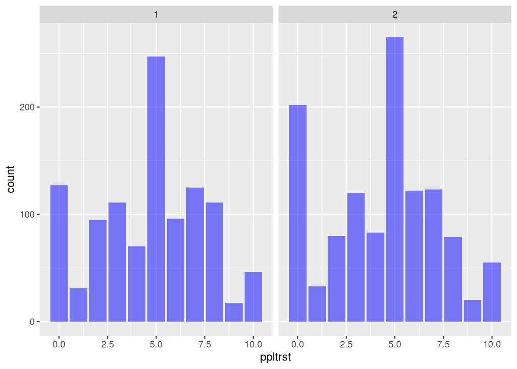

```r
#  nada que completar

ess_data_ES |>
  ggplot(aes(x = ppltrst)) +
  geom_bar(aes(y = after_stat(count)), fill = "blue", alpha = .5) +
  facet_grid(. ~ gndr)
```

Si queremos obtener una matriz de diagramas donde cada fila corresponde a una variable y cada columna a un género, necesitamos pasar el dataframe `ess_data_ES` en formato “long”: en lugar de tener una fila por cada entrevistado y 5 columnas `cntry`, `gndr`, `ppltrst`, `pplfair`, `pplhlp`, tendremos para cada entrevistado, tres filas pero solo cuatro columnas: `cntry`, `gndr`, y `variable` que contenga el nombre de la variable (tomará tres valores “ppltrst”, “pplfair”, “pplhlp”) y `valor` que contenga el valor que toma, para este entrevistado, cada variable.

Para ello, se usa `pivot_longer` de la librería “tidyr”, ver [documentación](https://tidyr.tidyverse.org/reference/pivot_longer.html)

```r
#  nada que completar
ess_data_ES_long <- ess_data_ES |>
  pivot_longer(
    cols = starts_with("ppl"),
    names_to = "variable",
    values_to = "valor"
  )
head(ess_data_ES_long)
```

```
# A tibble: 6 × 5
   idno cntry  gndr variable valor
  <dbl> <chr> <dbl> <chr>    <dbl>
1 10009 ES        1 ppltrst      5
2 10009 ES        1 pplfair      5
3 10009 ES        1 pplhlp       5
4 10032 ES        1 ppltrst      5
5 10032 ES        1 pplfair      6
6 10032 ES        1 pplhlp       4
```

Por ejemplo, el primer entrevistado español contestó con un 5 a las tres preguntas.

Ahora podemos hacer la matriz siguiente:

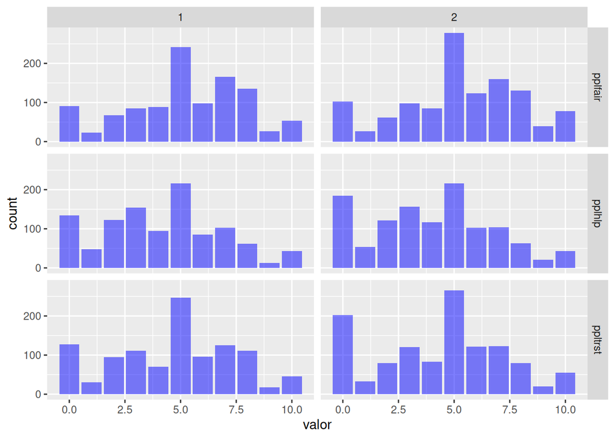

```r
#  nada que completar
ess_data_ES_long |>
  ggplot(aes(x = valor)) +
  geom_bar(aes(y = after_stat(count)), fill = "blue", alpha = .5) +
  facet_grid(variable ~ gndr)
```

**NotePara la estimación de la valoración promedio, un filtrado adicional**

Por los diagramas de barras anteriores, parece que una parte importante de los entrevistados contestan con un 0 a estas preguntas sobre su percepción de los demás. Puede corresponder a una reacción emocional, puesto que queremos obtener la valoración promedio y construir un intervalo de confianza usando un modelo normal, vamos además a eliminar los 0 del conjunto. De la misma manera, quitamos también los valores 10 del conjunto.  
PD: No se trata de un procedimiento muy justificado, es más para poder ilustrar la construcción de intervalos!

Eliminad los valores 0 y 10 en `ess_data_ES_long` para las variables `ppltrst`, `pplfair`, `pplhlp`

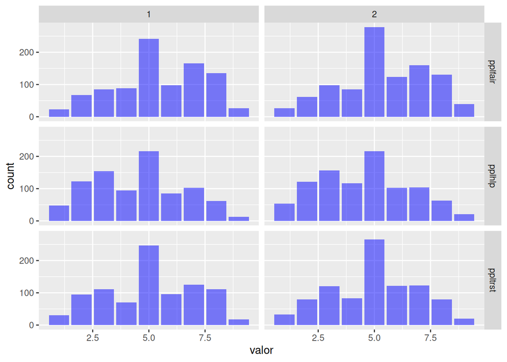

```r
#  nada que completar
ess_data_ES_long <- ess_data_ES_long |>
  filter(between(valor, 1, 9))

ess_data_ES_long |>
  ggplot(aes(x = valor)) +
  geom_bar(aes(y = after_stat(count)), fill = "blue", alpha = .5) +
  facet_grid(variable ~ gndr)
```

Podemos ahora volver a `ess_data_ES` en formato “ancho”, con `pivot_wider`, los valores que hemos filtrado se transformarán en valores faltantes, y no intervendrán en los cálculos

```r
# Nada que completar
ess_data_ES <- ess_data_ES_long |>
  pivot_wider(
    names_from = variable,
    values_from = valor
  )
str_glue("El conjunto ess_data_ES tiene {nrow(ess_data_ES)} filas y {ncol(ess_data_ES)} columnas")
```

```
El conjunto ess_data_ES tiene 2090 filas y 6 columnas
```

```r
print("Número de datos faltantes por columnas:")
```

```
[1] "Número de datos faltantes por columnas:"
```

```r
ess_data_ES |>
  summarise(across(ppltrst:pplhlp, list(faltantes = \(x) sum(is.na(x))))) |>
  print()
```

```
# A tibble: 1 × 3
  ppltrst_faltantes pplfair_faltantes pplhlp_faltantes
              <int>             <int>            <int>
1               262               156              236
```

**Tip`pivot_wider`**

Para esta última operación con `pivot_wider`, nos hemos aprovechado del hecho de disponer de una columna (`idno`) que identificaba el entrevistado de manera única.

## Cálculo de un intervalo de confianza para la valoración promedio

**TipDistribucion muestral para la media**

Vamos a calcular un intervalo de confianza para la valoración promedio para cada una de las tres variables, para los datos de España

Empezad por definir una función `calcular_error_ic` que admita como parámetros un vector `x`, un valor `alpha` entre 0 y 1, y que devuelva el margen de error asociado a un IC para $\mu$, suponiendo que `x` es una realización de una m.a.s de un $\mathcal{N}(\mu, \sigma^2)$, con $\sigma$ desconocida.

```r
# Completar aquí
calcular_error_ic <- function(x, alpha, na.rm = FALSE) {
  if (na.rm) x <- x[!is.na(x)]
  n <- length(x)
  if (n < 2) {
    return(NA_real_)
  }

  qt(1 - alpha / 2, df = n - 1) * sd(x) / sqrt(n)
}
# Fin Completar aquí
x <- c(5.52, 6.02, 4.75, 9.29, 2.91, 4.25, 4.87, 4.72, 3.51, 7.95)
calcular_error_ic(x, 0.05)
```

```
[1] 1.396311
```

Usando `summarise` y `across` como en la primera parte, obtened un tibble que contenga para cada una de las tres variables `ppltrst`, `pplfair`, `pplhlp`, la media y el margen de error al 95% del IC correspondiente.

```r
# Completar aquí
ess_data_ES |>
  summarise(
    across(
      starts_with("ppl"),
      list(
        media = \(x) mean(x, na.rm = TRUE),
        error = \(x) calcular_error_ic(x, alpha = 0.05, na.rm = TRUE)
      ),
      .names = "{col}_{fn}"
    )
  )
```

```
# A tibble: 1 × 6
  ppltrst_media ppltrst_error pplfair_media pplfair_error pplhlp_media
          <dbl>         <dbl>         <dbl>         <dbl>        <dbl>
1          5.02        0.0910          5.42        0.0878         4.54
# ℹ 1 more variable: pplhlp_error <dbl>
```

```r
# Fin Completar aquí
```

Podemos ahora distinguir los géneros y obtener las mismas columnas:

```r
# Completar aquí
ess_data_ES |>
  group_by(gndr) |>
  summarise(
    across(
      starts_with("ppl"),
      list(
        media = \(x) mean(x, na.rm = TRUE),
        error = \(x) calcular_error_ic(x, alpha = 0.05, na.rm = TRUE)
      ),
      .names = "{col}_{fn}"
    ),
    .groups = "drop"
  )
```

```
# A tibble: 2 × 7
   gndr ppltrst_media ppltrst_error pplfair_media pplfair_error pplhlp_media
  <dbl>         <dbl>         <dbl>         <dbl>         <dbl>        <dbl>
1     1          5.05         0.133          5.42         0.127         4.52
2     2          4.99         0.125          5.42         0.122         4.56
# ℹ 1 more variable: pplhlp_error <dbl>
```

```r
# Fin Completar aquí
```

# Comparación de las respuestas a dos preguntas.

Queremos comprobar si hay diferencias entre las respuestas de los entrevistados a la pregunta `ppltrst` (“¿Diría usted que, por lo general, se puede confiar en la mayoría de la gente, o que nunca se es lo bastante prudente en el trato con los demás?”) y a la pregunta `pplfair` (“¿Cree que la mayoría de la gente intentaría aprovecharse de usted si pudiera, o que sería honrada con usted?”.

## Exploración gráfica

Representad gráficamente las respuestas a la pregunta `pplfair` en función de las respuestas a la pregunta `ppltrst` para España.

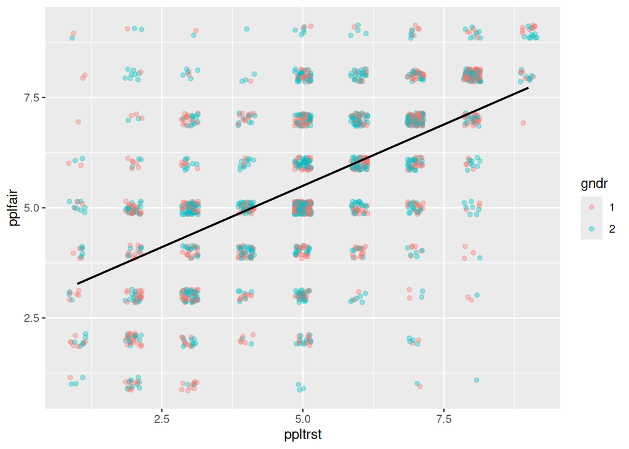

```r
# Completar aquí
ess_data_ES |>
  ggplot(aes(x = ppltrst, y = pplfair, color = factor(gndr))) +
  geom_jitter(width = 0.15, height = 0.15, alpha = 0.35, size = 1.4) +
  geom_smooth(method = "lm", se = FALSE, linewidth = 0.8, color = "black") +
  labs(x = "ppltrst", y = "pplfair", color = "gndr")
```

```r
# Fin Completar aquí
```

**TipPara visualizar mejor:**

Hemos usado `geom_jitter` que es parecido a `geom_point` pero que mueve cada punto un poquito de manera aleatoria, lo que permite ver mejor al evitar los solapamientos. (podéis probar con `geom_point` para ver la diferencia

Por lo que vemos, y como era de esperar, las respuestas a las dos preguntas no son independientes. Para compararlas, vamos a hacer un intervalo de confianza para su diferencia.

Obtened un intervalo de confianza al 95% para el promedio de la diferencia entre la respuesta a `pplfair` y `ppltrst`, desglosando el resultado por género.

```r
# Completar aquí
ess_data_ES |>
  group_by(gndr) |>
  summarise(
    media_diff = mean(pplfair - ppltrst, na.rm = TRUE),
    error = calcular_error_ic(pplfair - ppltrst, alpha = 0.05, na.rm = TRUE),
    ic_inf = media_diff - error,
    ic_sup = media_diff + error,
    .groups = "drop"
  )
```

```
# A tibble: 2 × 5
   gndr media_diff error ic_inf ic_sup
  <dbl>      <dbl> <dbl>  <dbl>  <dbl>
1     1      0.425 0.117  0.308  0.542
2     2      0.526 0.123  0.403  0.649
```

```r
# Fin Completar aquí
```

**NoteQué concluis?**

Hay una diferencia entre la valoración a las dos preguntas?

# Diferencia entre las valoraciones a la misma pregunta por hombres y mujeres.

Vamos a construir un IC para la diferencia de las valoraciones promedio a la pregunta `ppltrst` entre hombres y mujeres.

**TipDistribuciones muestrales para dos medias.**

Definid una función que se llame `calcular_error_diferencia` que admite como argumentos un vector `x`, un vector `y`, el nivel de riesgo `alpha` y un booleano `varianzas_iguales`, que devuelva el margen de error del IC con nivel de confianza $100 \times (1 - \alpha)$ para la diferencia de medias $\mu_X - \mu_Y$.

```r
# completar aquí
calcular_error_diferencia <- function(x, y, alpha, varianzas_iguales, na.rm = FALSE) {
  if (na.rm) {
    x <- x[!is.na(x)]
    y <- y[!is.na(y)]
  }

  nx <- length(x)
  ny <- length(y)
  if (nx < 2 || ny < 2) {
    return(NA_real_)
  }

  sx2 <- var(x)
  sy2 <- var(y)

  if (varianzas_iguales) {
    sp2 <- ((nx - 1) * sx2 + (ny - 1) * sy2) / (nx + ny - 2)
    se <- sqrt(sp2 * (1 / nx + 1 / ny))
    gl <- nx + ny - 2
  } else {
    se <- sqrt(sx2 / nx + sy2 / ny)
    gl <- (sx2 / nx + sy2 / ny)^2 /
      ((sx2 / nx)^2 / (nx - 1) + (sy2 / ny)^2 / (ny - 1))
  }

  qt(1 - alpha / 2, df = gl) * se
}

# Fin Completar aquí
x <- c(5.52, 6.02, 4.75, 9.29, 2.91, 4.25, 4.87, 4.72, 3.51, 7.95)
y <- c(7.81, 8.90, 6.72, 9.75, 4.13, 6.31, 3.66, 6.91, 8.40, 5.74)
calcular_error_diferencia(x, y, 0.05, varianzas_iguales = FALSE)
```

```
[1] 1.844125
```

Para España, obtened el IC al 95% para la diferencia entre las valoraciones promedio de hombres y mujeres para la pregunta `ppltrst`, sin suponer las varianzas iguales.

```r
# Completar aquí
x <- ess_data_ES |>
  filter(gndr == 1) |>
  pull(ppltrst)

y <- ess_data_ES |>
  filter(gndr == 2) |>
  pull(ppltrst)

media_diff <- mean(x, na.rm = TRUE) - mean(y, na.rm = TRUE)
error <- calcular_error_diferencia(x, y, 0.05, varianzas_iguales = FALSE, na.rm = TRUE)

tibble(
  ic_inf = media_diff - error,
  ic_sup = media_diff + error
)
```

```
# A tibble: 1 × 2
  ic_inf ic_sup
   <dbl>  <dbl>
1 -0.120  0.244
```

```r
# Fin Completar aquí
```

## Suponiendo las varianzas iguales.

Obtened la varianza para las respuestas a la pregunta `ppltrst`, desglosando por género.

```r
# Completar aquí
ess_data_ES |>
  group_by(gndr) |>
  summarise(
    n = sum(!is.na(ppltrst)),
    var_ppltrst = var(ppltrst, na.rm = TRUE),
    sd_ppltrst = sd(ppltrst, na.rm = TRUE),
    .groups = "drop"
  )
```

```
# A tibble: 2 × 4
   gndr     n var_ppltrst sd_ppltrst
  <dbl> <int>       <dbl>      <dbl>
1     1   903        4.13       2.03
2     2   925        3.74       1.93
```

```r
# Fin Completar aquí
```

Los valores son parecidos, para confirmarlo, podemos construir un IC para el ratio de varianzas.

Definid una función `calcular_ic_cociente_varianzas` que admite como argumentos un vector `x`, un vector `y`, el nivel de riesgo `alpha`, y que devuelva un tibble con dos columnas, una llamada `izq` y otra llamada `der` que contengan los dos extremos del IC para el cociente de las varianzas $\sigma_x^2/\sigma_y^2$.

```r
# Completar aquí


calcular_ic_cociente_varianzas <- function(x, y, alpha, na.rm = FALSE) {
  nx <- length(x)
  ny <- length(y)
  varx <- var(x, na.rm = na.rm)
  vary <- var(y, na.rm = na.rm)
  cociente <- varx / vary
  tibble(
    izq = cociente / qf(1 - alpha / 2, df1 = nx - 1, df2 = ny - 1),
    der = cociente / qf(alpha / 2, df1 = nx - 1, df2 = nx - 1)
  )
}
# Fin Completar aquí
x <- c(5.52, 6.02, 4.75, 9.29, 2.91, 4.25, 4.87, 4.72, 3.51, 7.95)
y <- c(7.81, 8.90, 6.72, 9.75, 4.13, 6.31, 3.66, 6.91, 8.40, 5.74)
calcular_ic_cociente_varianzas(x, y, 0.05)
```

```
# A tibble: 1 × 2
    izq   der
  <dbl> <dbl>
1 0.243  3.94
```

Para España, obtened el IC al 95% para el cociente de las varianzas de las respuestas de hombres y mujeres para la pregunta `ppltrst`.

```r
# Completar aquí
x <- ess_data_ES |>
  filter(gndr == 1) |>
  pull(ppltrst)

y <- ess_data_ES |>
  filter(gndr == 2) |>
  pull(ppltrst)

calcular_ic_cociente_varianzas(x, y, alpha = 0.05, na.rm = TRUE)
```

```
# A tibble: 1 × 2
    izq   der
  <dbl> <dbl>
1 0.979  1.25
```

```r
# Fin Completar aquí
```

**NoteQué concluis?**

Volved a calcular el IC para España al 95% para la diferencia entre las valoraciones promedio de hombres y mujeres para la pregunta `ppltrst`, pero suponiendo ahora las varianzas iguales.

```r
# Completar aquí
x <- ess_data_ES |>
  filter(gndr == 1) |>
  pull(ppltrst)

y <- ess_data_ES |>
  filter(gndr == 2) |>
  pull(ppltrst)

media_diff <- mean(x, na.rm = TRUE) - mean(y, na.rm = TRUE)
error_eq <- calcular_error_diferencia(x, y, 0.05, varianzas_iguales = TRUE, na.rm = TRUE)

tibble(
  ic_inf = media_diff - error_eq,
  ic_sup = media_diff + error_eq
)
```

```
# A tibble: 1 × 2
  ic_inf ic_sup
   <dbl>  <dbl>
1 -0.120  0.244
```

```r
# Fin Completar aquí
```

**NoteQué concluis?**

Comparad con el IC obtenido si no suponemos las varianzas iguales.

# Parte opcional: consideramos los datos desde 2002

Cargad todos los ficheros correspondientes al ESS, y obtened, para España, las mismas columnas pero desglosando por género y por año.  
Para ello, empezad por escribid una función `cargar_ESS_file` que coja el nombre del fichero y devuelva un tibble preparado, con los datos filtrados tal como lo hemos visto para 2020

```r
# nada que completar
cargar_ESS_file <- function(file_name) {
  ess_data <- read_csv(
    paste0(DATA_DIRECTORY, file_name),
    col_select = c(idno, cntry, gndr, ppltrst, pplfair, pplhlp),
    show_col_types = FALSE
  )
  ess_data_ES_long <- ess_data |>
    filter(cntry == "ES") |>
    pivot_longer(
      cols = starts_with("ppl"),
      names_to = "variable",
      values_to = "valor"
    ) |>
    filter(between(valor, 1, 9) & gndr %in% 1:2)
  ess_data_ES <- ess_data_ES_long |>
    pivot_wider(
      names_from = variable,
      values_from = valor
    )
  ess_data_ES
}

glimpse(cargar_ESS_file("ESS1e06_6.csv"))
```

```
Rows: 1,673
Columns: 6
$ idno    <dbl> 2, 5, 8, 13, 15, 22, 23, 25, 27, 31, 36, 37, 38, 41, 42, 43, 4…
$ cntry   <chr> "ES", "ES", "ES", "ES", "ES", "ES", "ES", "ES", "ES", "ES", "E…
$ gndr    <dbl> 2, 1, 1, 1, 1, 1, 2, 1, 2, 2, 2, 1, 2, 1, 2, 1, 2, 2, 1, 1, 2,…
$ ppltrst <dbl> 5, 3, 5, 2, 2, 8, 4, 7, 8, 5, 1, 3, 3, 5, 3, 6, 4, 7, 3, 5, 2,…
$ pplfair <dbl> 4, 3, 3, 5, 3, 7, 7, 7, 8, 8, 5, 2, 2, 4, 3, 2, 5, 5, 3, 3, NA…
$ pplhlp  <dbl> 5, 3, 8, 4, 2, 5, 3, 4, 5, 4, 2, 2, 4, 3, 3, 4, 3, 7, 2, 3, 5,…
```

Podéis ahora usar `map_dfr` para crear un único dataframe que contenga los datos de todos los años. Pasaremos a `map_dfr` una lista cuyos nombres son los años, y usaremos el argumento `.id` de `map_dfr`.

```r
ESS_FILE_NAMES <- c(
  "2002" = "ESS1e06_6.csv",
  "2004" = "ESS2e03_6.csv",
  "2006" = "ESS3e03_7.csv",
  "2008" = "ESS4e04_5.csv",
  "2010" = "ESS5e03_4.csv",
  "2012" = "ESS6e02_5.csv",
  "2014" = "ESS7e02_2.csv",
  "2016" = "ESS8e02_2.csv",
  "2018" = "ESS9e03_1.csv",
  "2020" = "ESS10SC.csv"
)
# nada quecompletar
ess_data <- map_dfr(ESS_FILE_NAMES, .f = cargar_ESS_file, .id = "year")

glimpse(ess_data)
```

```
Rows: 19,031
Columns: 7
$ year    <chr> "2002", "2002", "2002", "2002", "2002", "2002", "2002", "2002"…
$ idno    <dbl> 2, 5, 8, 13, 15, 22, 23, 25, 27, 31, 36, 37, 38, 41, 42, 43, 4…
$ cntry   <chr> "ES", "ES", "ES", "ES", "ES", "ES", "ES", "ES", "ES", "ES", "E…
$ gndr    <dbl> 2, 1, 1, 1, 1, 1, 2, 1, 2, 2, 2, 1, 2, 1, 2, 1, 2, 2, 1, 1, 2,…
$ ppltrst <dbl> 5, 3, 5, 2, 2, 8, 4, 7, 8, 5, 1, 3, 3, 5, 3, 6, 4, 7, 3, 5, 2,…
$ pplfair <dbl> 4, 3, 3, 5, 3, 7, 7, 7, 8, 8, 5, 2, 2, 4, 3, 2, 5, 5, 3, 3, NA…
$ pplhlp  <dbl> 5, 3, 8, 4, 2, 5, 3, 4, 5, 4, 2, 2, 4, 3, 3, 4, 3, 7, 2, 3, 5,…
```

Después de transformar `year` en numérico, obtened para cada año y desglosando por género la media y el margen de error para cada una de las tres variables

```r
# nada que completar
ess_data |>
  mutate(year = as.numeric(year)) |>
  group_by(gndr, year) |>
  summarise(
    across(
      starts_with("ppl"),
      list(
        media = \(x) mean(x, na.rm = TRUE),
        error = \(x) calcular_error_ic(x, 0.05, na.rm = TRUE)
      ),
      .names = "{col}_{fn}"
    )
  )
```

```
# A tibble: 20 × 8
# Groups:   gndr [2]
    gndr  year ppltrst_media ppltrst_error pplfair_media pplfair_error
   <dbl> <dbl>         <dbl>         <dbl>         <dbl>         <dbl>
 1     1  2002          5.06         0.141          5.31         0.139
 2     1  2004          5.19         0.127          5.35         0.128
 3     1  2006          5.22         0.122          5.40         0.120
 4     1  2008          4.99         0.105          5.33         0.104
 5     1  2010          5.31         0.112          5.39         0.108
 6     1  2012          5.29         0.117          5.46         0.121
 7     1  2014          5.04         0.120          5.31         0.117
 8     1  2016          5.18         0.128          5.41         0.123
 9     1  2018          5.37         0.124          5.52         0.128
10     1  2020          5.05         0.133          5.42         0.127
11     2  2002          4.95         0.139          5.33         0.135
12     2  2004          5.01         0.138          5.25         0.140
13     2  2006          5.13         0.116          5.45         0.117
14     2  2008          4.97         0.105          5.29         0.103
15     2  2010          5.18         0.111          5.30         0.109
16     2  2012          5.34         0.118          5.54         0.118
17     2  2014          4.86         0.130          5.44         0.131
18     2  2016          5.10         0.128          5.54         0.122
19     2  2018          5.18         0.141          5.65         0.134
20     2  2020          4.99         0.124          5.43         0.121
# ℹ 2 more variables: pplhlp_media <dbl>, pplhlp_error <dbl>
```

**TipEJERCICIO**

1. Queremos comprobar ahora si hay diferencias entre las respuestas de los entrevistados a la pregunta `pplfair` (“¿Cree que la mayoría de la gente intentaría aprovecharse de usted si pudiera, o que sería honrada con usted?” y las respuestas de los entrevistados a la pregunta `pplhlp` “¿Diría usted que la mayoría de las veces la gente intenta ayudar a los demás o que principalmente mira por sí misma?”.Para España:
- ¿Son las respuestas a ambas preguntas independientes? justificad vuestra respuesta
- Calculad un intervalo de confianza para la diferencia de las respuestas medias con una confianza del 98%.

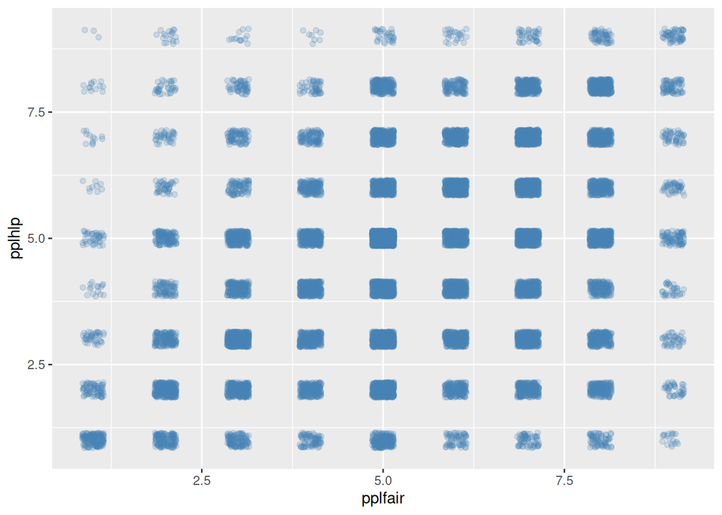

```r
# Completar aquí
# Exploración visual
ess_data |>
  ggplot(aes(x = pplfair, y = pplhlp)) +
  geom_jitter(width = 0.15, height = 0.15, alpha = 0.2, color = "steelblue") +
  labs(x = "pplfair", y = "pplhlp")
```

```r
# Contraste de independencia (asociación en tabla de contingencia)
tabla <- table(ess_data$pplfair, ess_data$pplhlp)
chisq.test(tabla)
```

```
    Pearson's Chi-squared test

data:  tabla
X-squared = 4933.9, df = 64, p-value < 2.2e-16
```

```r
# IC 98% para E[pplfair - pplhlp]
d <- ess_data$pplfair - ess_data$pplhlp
media_d <- mean(d, na.rm = TRUE)
error_d <- calcular_error_ic(d, alpha = 0.02, na.rm = TRUE)

tibble(
  media_diff = media_d,
  ic_inf = media_d - error_d,
  ic_sup = media_d + error_d
)
```

```
# A tibble: 1 × 3
  media_diff ic_inf ic_sup
       <dbl>  <dbl>  <dbl>
1      0.836  0.797  0.875
```

```r
# Fin Completar aquí
```

**TipEJERCICIO**

2. Consideramos ahora en la variable `pplhlp` y queremos estudiar si hay diferencia en las valoraciones entre hombres y mujeres. Para España
- Obtened el IC al 98% para la diferencia entre las valoraciones promedio de hombres y mujeres para la pregunta `pplhlp`, sin suponer las varianzas iguales.
- Obtened el IC al 98% para el cociente de las varianzas de las respuestas de hombres y mujeres para la pregunta ``pplhlp`.¿Que concluís?

```r
# Completar aquí
x <- ess_data |>
  filter(gndr == 1) |>
  pull(pplhlp)

y <- ess_data |>
  filter(gndr == 2) |>
  pull(pplhlp)

# IC 98% para diferencia de medias (sin varianzas iguales)
media_diff <- mean(x, na.rm = TRUE) - mean(y, na.rm = TRUE)
error <- calcular_error_diferencia(x, y, alpha = 0.02, varianzas_iguales = FALSE, na.rm = TRUE)

ic_dif_medias_98 <- tibble(
  ic_inf = media_diff - error,
  ic_sup = media_diff + error
)

# IC 98% para cociente de varianzas
ic_cociente_var_98 <- calcular_ic_cociente_varianzas(x, y, alpha = 0.02, na.rm = TRUE)

list(
  IC_diferencia_medias_98 = ic_dif_medias_98,
  IC_cociente_varianzas_98 = ic_cociente_var_98
)
```

```
$IC_diferencia_medias_98
# A tibble: 1 × 2
  ic_inf   ic_sup
   <dbl>    <dbl>
1 -0.137 0.000370

$IC_cociente_varianzas_98
# A tibble: 1 × 2
    izq   der
  <dbl> <dbl>
1 0.933  1.03
```

```r
# Fin Completar aquí
```